# task11

Karolina

2016 m lapkritis 10 d

Pakete datasets yra duomenų masyvas longley. Iš šio kintamųjų padarykite tiesinę regresiją, kur prognozuojamas kintamasis būtų GNP, o regresosius Employed. Jums reikia:

1. Įvertinti paprastosios tiesinės regresijos modelį. Pateikti modelio summary ir pakomentuoti ką reiškia gauti skaičiai. Kaip interpretuoti gautus rezultatus?

```r
library('datasets')
data.frame(longley$GNP, longley$Employed) # sukuriama lentele is GNP ir Employed
```

```
##    longley.GNP longley.Employed
## 1      234.289           60.323
## 2      259.426           61.122
## 3      258.054           60.171
## 4      284.599           61.187
## 5      328.975           63.221
## 6      346.999           63.639
## 7      365.385           64.989
## 8      363.112           63.761
## 9      397.469           66.019
## 10     419.180           67.857
## 11     442.769           68.169
## 12     444.546           66.513
## 13     482.704           68.655
## 14     502.601           69.564
## 15     518.173           69.331
## 16     554.894           70.551
```

```r
x <- longley$Employed  # x'ui priskiriame Employed
y <- longley$GNP       # y'ui priskiriame GNP
modelis <- lm(y~x)         # sukuriame tiesines regresijos modeli lm, kuriame yra GNP ir Employed
summary(modelis)           # Modelio suvestine
```

```
##
## Call:
## lm(formula = y ~ x)
##
## Residuals:
##     Min      1Q  Median      3Q     Max
## -39.223 -11.920   0.855  14.882  23.555
##
## Coefficients:
##              Estimate Std. Error t value Pr(>|t|)
## (Intercept) -1430.482     89.361  -16.01 2.15e-10 ***
## x              27.836      1.366   20.37 8.36e-12 ***
## ---
## Signif. codes:  0 '***' 0.001 '**' 0.01 '*' 0.05 '.' 0.1 ' ' 1
##
## Residual standard error: 18.58 on 14 degrees of freedom
## Multiple R-squared:  0.9674, Adjusted R-squared:  0.965
## F-statistic: 415.1 on 1 and 14 DF,  p-value: 8.363e-12
```

Isvesties paaiskinimas :

Residuals: is esmes rodo skirtuma, kiek prognozuojami duomenys gali skirtis nuo stebimu.

Coefficients: si isvesties dalis yra apie koeficientus. Teoriskai, paprastoje tiesineje regresijoje, koeficientai yra dvi nezinomos konstantos pateikiancios intercept (-1430.482) ir slope (27.836) terminus tiesineje regresijoje.

Residual standard error: yra tiesines regresijos kokybes matmuo. Teoriskai, kiekviena tiesine regresija turi error termina E. Neimanoma visiskai tiksliai prognozuoti.

Multiple R-squared, Adjusted R-squared: determinacijos koeficientas; R kvadratu statistika nurodo kaip modelis priema esamus duomenis. Visalaika tarp 0 ir 1. Musu atveju R kvadratu yra 0.9674 arba 97% pakitimas, rastas regresoriuje(Employed) gali but paaiskinamas prognozuojanciojo kintamojo(GNP).

2. Padarykite modelio prognozes taškuose 62,65,68.

```r
naujasx <- c(62, 65, 68)                          #norimu prognozuoti reiksmiu vektorius
z = predict(modelis, newdata=data.frame(x=naujasx)) #prognozuojamos reiksmes
z                                           #isvedamos prognozuojamos reiksmes
```

```
##        1        2        3
## 295.3656 378.8743 462.3831
```

3. Išbrėžkite kintamųjų sklaidos diagramą kartu su tiesinės regresijos tiese ir naujomis prognozėmis. Grafiką pateikite su pilna legenda, kurioje būtų nurodyti visi žymėjimai.

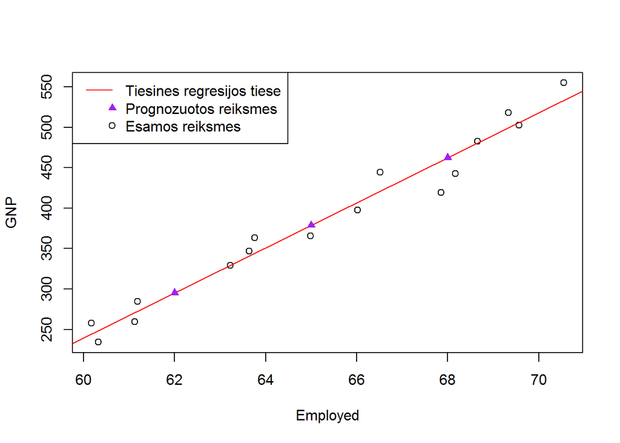

```r
plot(x,y, xlab="Employed", ylab="GNP")             #grafikas
abline(modelis, col="red")                           #tiesines regresijos tiese
points(naujasx, z, col="purple", pch=17)                 #prognozuojamos reiksmes
legend(x="topleft", legend = c("Tiesines regresijos tiese", "Prognozuotos reiksmes", "Esamos reiksmes"), col = c("red", "purple", "black"), lty = c(1, NA, NA), pch = c(NA, 17, 1), merge = FALSE, cex = 1)#legenda
```

Source : Grupioku pagalba